# Exploratory analysis: Formal procedures

This exploratory analysis focuses on the Formal procedures dimension and includes various data summaries in table and graphical forms. The dimension is concpetualised as Political vs. Legal.

# List of items

The Formal Procedures scale has been constructed on the basis of these items:

| Item | Question |
| --- | --- |
| 13 | Is there a formal admissibility check? |
| 14 | Who decides about the formal admissibility? |
| 15 | Is there a legal remedy against the decision on formal admissibility? |
| 16 | Who decides about the claim for remedy in the formal admissibility procedure? |
| 17 | Who can initiate the formal remedy procedure (state actor - initiator - anyone)? |
| 18 | Does the formal admissibility procedure take place before the signature collection? |
| 20 | Do participants have a right to be heard in the formal admissibility procedure? |
| 21 | Is there an evidentiary procedure in the formal admissibility procedure? |
| 22 | Are the legal consequences of the formal admissibility procedures binding? |
| 23 | Is invalidity the legal consequence of formal inadmissibility? |

# Checking data

Two most important points:

1. Formal procedures seem to have 2 filter items, 13 and 15. These are left out of subsequent analysis.
2. For now, Item 18, on formal admissibility before signature collection, is EXCLUDED since it does not apply to most number of instruments.

# Data Summaries

In some of these summaries, the original labels are used “Yes” (Legal) vs “No” (Political).

#### Table of Country / Instrument distribution for item 13 on Formal admisability check

Note NA means instrument not available

Note “Yes” (Legal) vs “No” (Political).

| Country | Agenda | Executive | Legislature | Proactive | Rejective | Subnational |
| --- | --- | --- | --- | --- | --- | --- |
| Albania | No | No | No | Yes | Yes | NA |
| Austria | Yes | No | No | NA | NA | NA |
| Bulgaria | No | No | No | Yes | NA | No |
| Croatia | NA | No | No | Yes | Yes | NA |
| Denmark | Yes | NA | No | NA | NA | NA |
| Estonia | Yes | NA | Yes | NA | NA | NA |
| Finland | No | NA | No | NA | NA | NA |
| France | NA | Yes | Yes | NA | NA | NA |
| Georgia | Yes | No | No | Yes | NA | NA |
| Greece | Yes | No | No | NA | NA | NA |
| Hungary | NA | Yes | NA | Yes | NA | NA |
| Italy | Yes | NA | Yes | NA | Yes | Yes |
| Latvia | Yes | NA | No | Yes | Yes | NA |
| Liechtenstein | Yes | NA | No | Yes | Yes | Yes |
| Lithuania | Yes | NA | No | Yes | NA | NA |
| Moldova | NA | Yes | Yes | Yes | NA | NA |
| Poland | Yes | No | No | No | NA | NA |
| Romania | Yes | No | NA | NA | NA | NA |
| Russia | Yes | NA | NA | Yes | Yes | NA |
| Serbia | No | No | No | No | NA | NA |
| Slovakia | Yes | No | No | Yes | Yes | NA |
| Spain | Yes | No | No | NA | NA | NA |
| Switzerland | NA | NA | NA | Yes | No | Yes |
| Turkey | NA | No | NA | NA | NA | NA |
| UK | NA | NA | No | NA | NA | NA |

#### Distribution of Yes vs. No answers for item 13 on formal admisability check

Note “Yes” (Legal) vs “No” (Political).

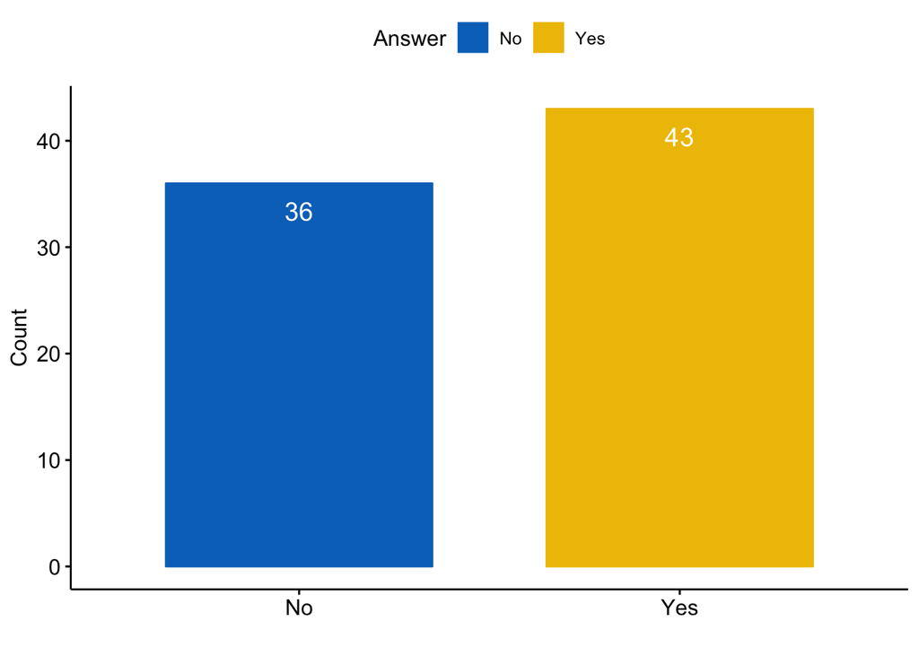

#### Distribution of Yes vs. No answers per instrument for item 13 on Formal admisability check

Note “Yes” means Legal and “No” means Political

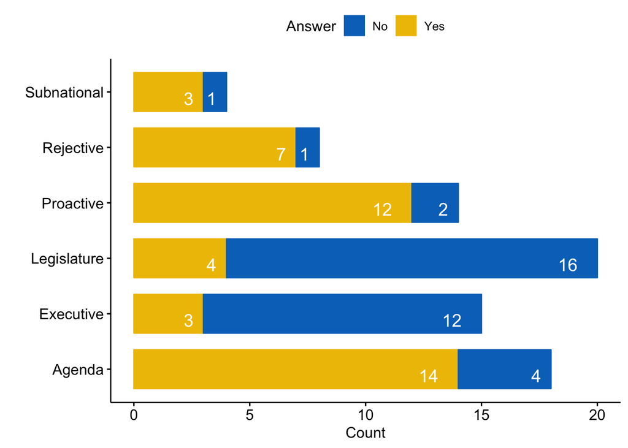

#### Distribution of items Legal vs. Political

*Note*: Filter Items 13 and 15 have been removed and so has item 18 (before signature collection)

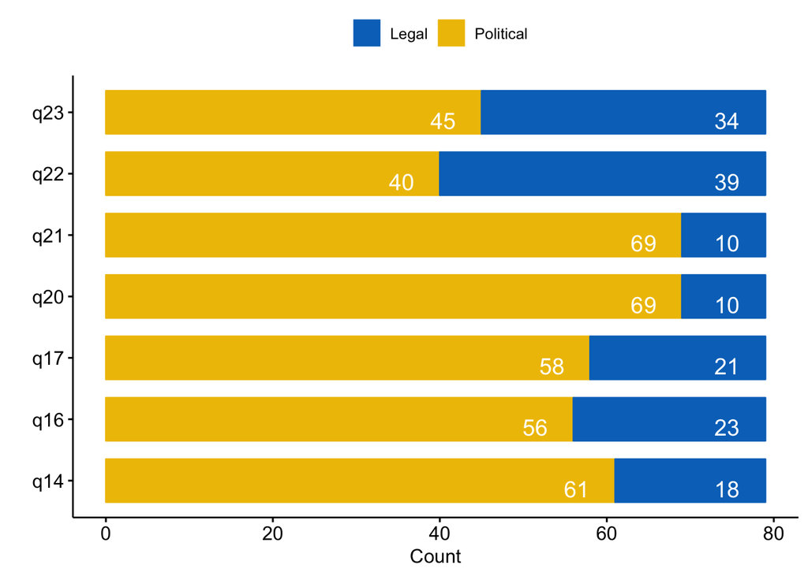

Probably the only thing to consider is items 21 and 20, and whether they may impact on the overall Legal dimension score.

#### Distribution of items Legal vs. Political grouped by Instrument

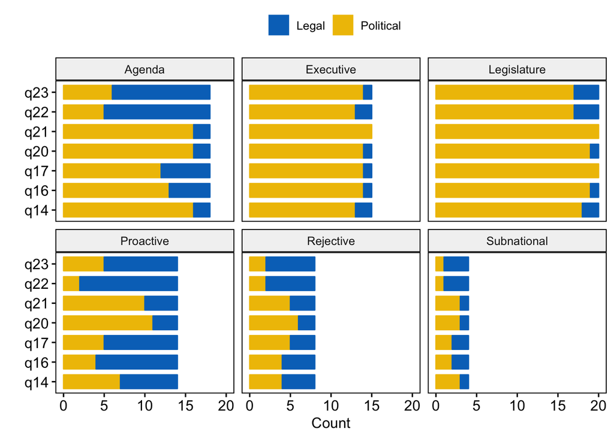

# Tabular data (aggregate per item)

An easy was to also look at the aggregate distribution is in an ordered table. Here we can see at the top of the table the highest “Legal” counts (in absolute numbers). [Column called N_Legal]

| Item | N_Political | N_Legal | Question |
| --- | --- | --- | --- |
| 22 | 40 | 39 | Are the legal consequences of the formal admissibility procedures binding? |
| 23 | 45 | 34 | Is invalidity the legal consequence of formal inadmissibility? |
| 16 | 56 | 23 | Who decides about the claim for remedy in the formal admissibility procedure? |
| 17 | 58 | 21 | Who can initiate the formal remedy procedure (state actor - initiator - anyone)? |
| 14 | 61 | 18 | Who decides about the formal admissibility? |
| 20 | 69 | 10 | Do participants have a right to be heard in the formal admissibility procedure? |
| 21 | 69 | 10 | Is there an evidentiary procedure in the formal admissibility procedure? |

# Country check

Another aspect worth checking is the Country impact. The visualisation below allows us to check how Country affects Formal prohibitions. It is organised by the items on Y axis and the Countries on the X axis. The bubble represent the count (i.e., how many prohibitions a country has per item). This is related to the number of instruments a country has; thus a country with 5, will have a maximum number of 5 prohibitions.

Visualising these country effects allows us to see whether a particular country is driving the count for a particular Item.

#### Matrix of ‘Legal’ value counts for each item organised by country

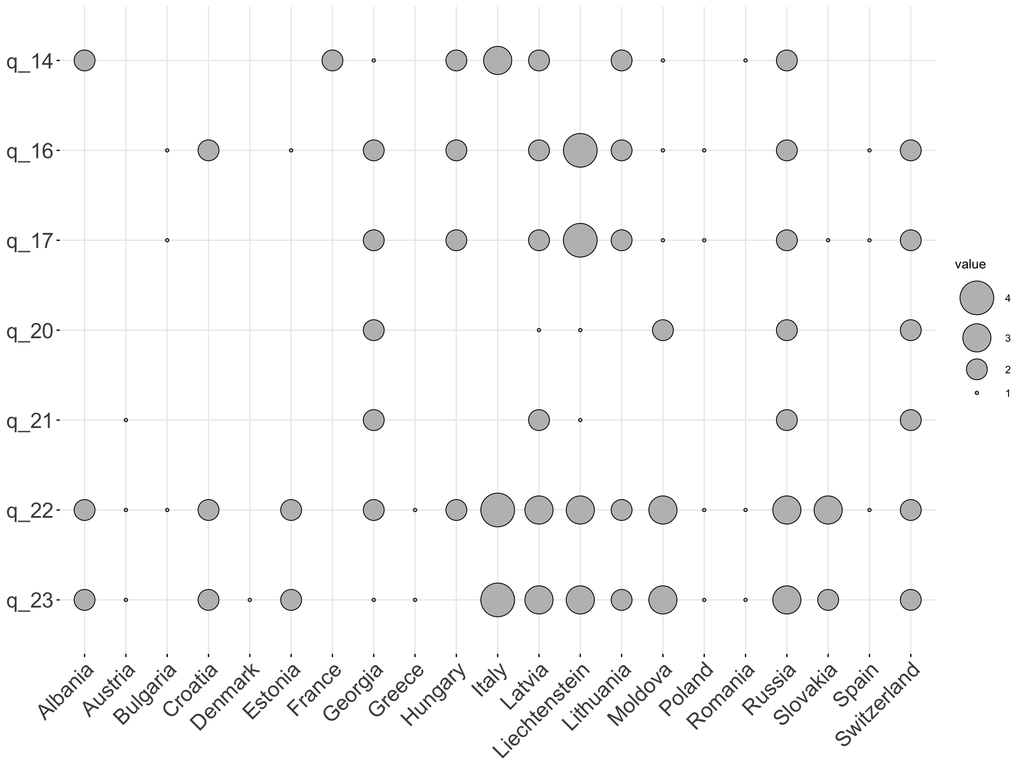

# Preliminary evaluation of scores

In the graph below we can place all cases on a putative Formal Procedures dimension (Political vs Legal).

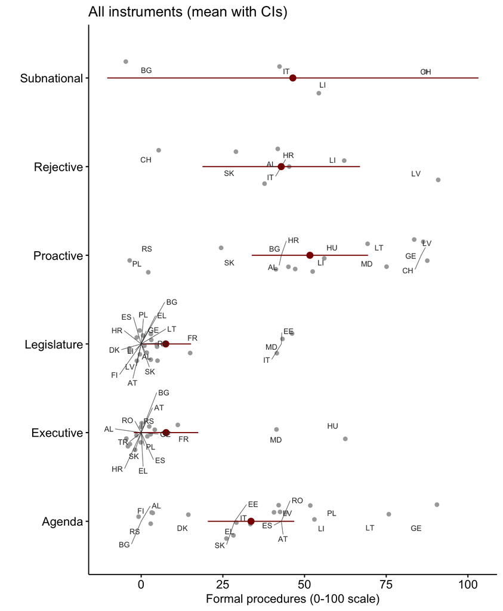